# Assignment 4

## Instructions

Please fork this to your repo (or copy it there). Make sure your repo is private, but shared with the course admin. Complete the assignment within your forked version of this file. Please start early, because this assignment is challenging and if you wait until the last moment, you will not be able to complete it.

Group: 19

Group members: Siqi, Arnav, Ruini

Assignment due date: November 30, 2021, 11:59PM

## Introduction

*Epstein-Barr Virus (EBV) is a herpes virus and the cause of mononucleosis. Like other herpes viruses, infected cells can remain in a latent phase in the infected person their entire lives. B-cells are the usual target of EBV. When infected, B-cells can become immortalized, and can be cultured in vitro as Lymphoblastoid Cell Lines (LCLs). Like some other viruses, this immortalization can predispose the individual to certain types of cancer. For instance, Hodgkin’s Lymphoma is derived from EBV-infected B cells.*

*Today, we’re going to look at gene expression data to see how EBV infection changes the transcriptome. We will be looking at B-cell and LCL RNA-seq data from 5 donors, where LCLs were made from each of the donor’s B-cells. Please start from this file and add code/code blocks/and commentary as needed.*

## Load data

*Load needed libraries (install any you don’t yet have - edgeR can be installed through BioConductor)*

*Load data:*

```r
rnaSeqData =  read.table(textConnection(readLines(gzcon(url(
  "https://ftp.ncbi.nlm.nih.gov/geo/series/GSE126nnn/GSE126379/suppl/GSE126379_BLCL_processed.txt.gz")))),
  sep="\t", stringsAsFactors = FALSE, header = TRUE)
```

*Reshape and re-label data to make it more usable.*

```r
#melt the data frame so that there is one row for every gene-sample-quantification.type (see below) combination
rnaSeqDataMelted = melt(rnaSeqData, id.vars=c("Chromosome", "Gene.Name", "Gene.ID", "Sum.of.Exon.Length.of.Gene"))
#label every value as a read count, but...
rnaSeqDataMelted$quantification.type = "counts";
#relabel those that are really RPKM
rnaSeqDataMelted$quantification.type[grepl(rnaSeqDataMelted$variable,pattern = "RPKM")] = "RPKM";
#get the donor (human) ID
rnaSeqDataMelted$donor = gsub(".*BLCL_([ABCDE])([12]).*", "\\1", rnaSeqDataMelted$variable)
#Get the identifier they use to distinguish LCLs from B-cells
rnaSeqDataMelted$celltype = gsub(".*BLCL_([ABCDE])([12]).*", "\\2", rnaSeqDataMelted$variable)
#They didn't label the cell types clearly, so we're going to guess their assignment and verify below
rnaSeqDataMelted$celltype[rnaSeqDataMelted$celltype=="1"]="B"
rnaSeqDataMelted$celltype[rnaSeqDataMelted$celltype=="2"]="LCL"
#Remove this, since we have already parsed out the needed info
rnaSeqDataMelted$variable=NULL;
rnaSeqDataMelted$Gene.Name=NULL; #we only use Gene.ID
rnaSeqDataMelted$sampleID = paste(rnaSeqDataMelted$celltype, rnaSeqDataMelted$donor, sep="_")
#divide data into read counts and RPKM
rnaSeqDataMeltedCounts = rnaSeqDataMelted[rnaSeqDataMelted$quantification.type=="counts",]
rnaSeqDataMeltedRPKM = rnaSeqDataMelted[rnaSeqDataMelted$quantification.type=="RPKM",]
#relabel "value" as appropriate, and remove the 'quantification.type' column
rnaSeqDataMeltedCounts$counts=rnaSeqDataMeltedCounts$value;
rnaSeqDataMeltedCounts$value=NULL;
rnaSeqDataMeltedCounts$quantification.type=NULL;
rnaSeqDataMeltedRPKM$RPKM=rnaSeqDataMeltedRPKM$value;
rnaSeqDataMeltedRPKM$value=NULL;
rnaSeqDataMeltedRPKM$quantification.type=NULL;
rm('rnaSeqDataMelted') # remove
```

*Here, `rnaSeqDataMeltedRPKM` contains the gene expression “Reads per kilobase of transcript per million reads”, and `rnaSeqDataMeltedCounts` contains the raw count data.*

## Questions

### Question 1

*It is always important to perform Quality Control on your data.*

#### Question 1a (2 pts)

*For some reason, the authors labeled the different cell types “1” and “2” in this table. We need to figure out which is which. You know that EBV induces the NF-kappaB pathway, and that the TNF gene should be highly induced. Make a graph that shows the relative gene expression levels of TNF (y axis) for both cell types (x axis), for each donor (colour or “fill”).*

*Enter your answer below:*

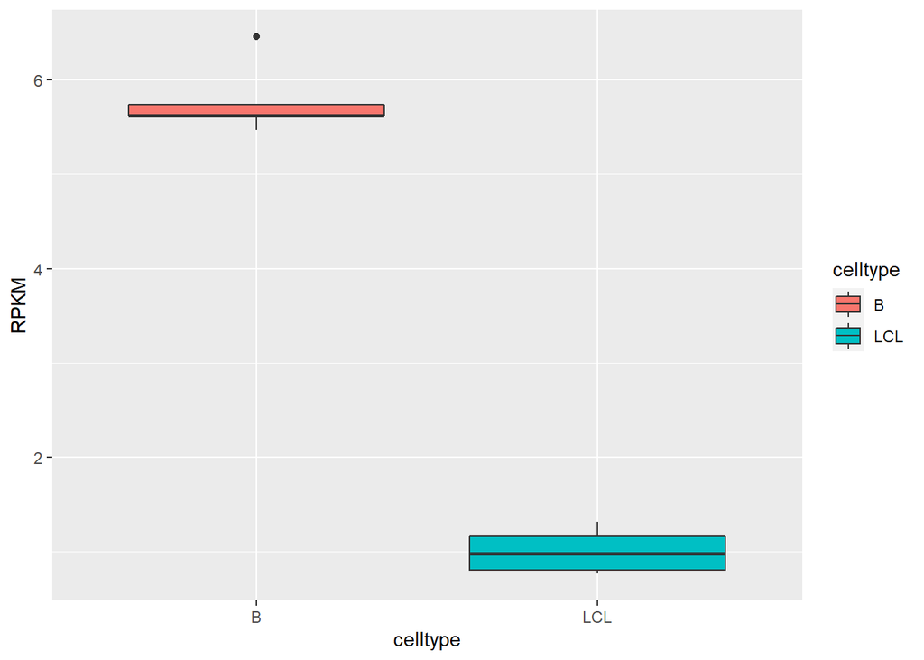

```r
TNF_exp<-rnaSeqDataMeltedRPKM[rnaSeqDataMeltedRPKM[,2]=="TNF" & rnaSeqDataMeltedRPKM[,7]>0,]
TNF_exp$RPKM<-log(TNF_exp$RPKM+1)/log(2)
ggplot(TNF_exp, aes(x=celltype, y=RPKM, fill=celltype))+geom_boxplot()
```

*Explain what you see. Are the celltype labels correct?* ### The cell type labels is wrong, because in this label, B cells have much higher TNF expression levels than LCL. Actually, the TNF gene should be highly induced in LCL. So 1 should be LCL and 2 should be B cells.

#### Question 1b ( 2pts)

*With RNA-seq data, it is important both that samples have sufficient coverage, and that the samples have similar coverage. Either case can lead to underpowered analysis, or misleading results. Calcualte the read coverage for each sample. Make a plot with read coverage on the y-axis (total number of reads) and the samples on the x-axis.*

```r
###Since the labels are wrong, we need set the correct ones
rnaSeqDataMeltedRPKM$celltype2<-rep("LCL",nrow(rnaSeqDataMeltedRPKM))
rnaSeqDataMeltedRPKM$celltype2[rnaSeqDataMeltedRPKM$celltype=="LCL"]<-"B"
rnaSeqDataMeltedRPKM$celltype<-NULL
colnames(rnaSeqDataMeltedRPKM)[7]<-"celltype"
rnaSeqDataMeltedRPKM$sampleID<-paste(rnaSeqDataMeltedRPKM$celltype,rnaSeqDataMeltedRPKM$donor,sep="_")
rnaSeqDataMeltedRPKM$sampleID<-paste(rnaSeqDataMeltedRPKM$celltype,rnaSeqDataMeltedRPKM$donor,sep="_")
rnaSeqDataMeltedCounts$celltype2<-rep("LCL",nrow(rnaSeqDataMeltedCounts))
rnaSeqDataMeltedCounts$celltype2[rnaSeqDataMeltedCounts$celltype=="LCL"]<-"B"
rnaSeqDataMeltedCounts$celltype<-NULL
colnames(rnaSeqDataMeltedCounts)[7]<-"celltype"
rnaSeqDataMeltedCounts$sampleID<-paste(rnaSeqDataMeltedCounts$celltype,rnaSeqDataMeltedCounts$donor,sep="_")

library(dplyr)
```

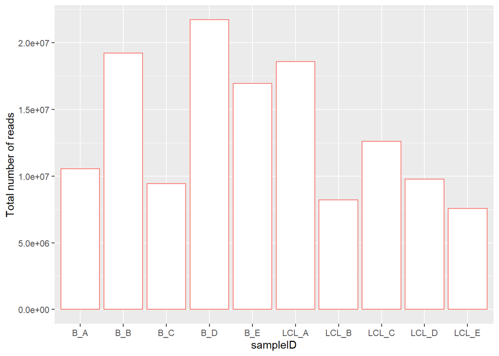

```r
coverage<-rnaSeqDataMeltedCounts %>% group_by(sampleID) %>% summarize("Total number of reads"=sum(counts))
ggplot(coverage, aes(x=sampleID, y=`Total number of reads`,color="green")) +geom_bar(stat="identity", fill="white")+theme(legend.position="none")
```

*Which sample has the least coverage?* ### LCL_E sample has the least coverage.

```r
coverage$sampleID[which.min(coverage$`Total number of reads`)]
```

```
## [1] "LCL_E"
```

*Which sample has the most?*

```r
coverage$sampleID[which.max(coverage$`Total number of reads`)]
```

```
## [1] "B_D"
```

### B_D has the most.

*What is the % difference between the max and min (relative to the min)?*

```r
(max(coverage$`Total number of reads`)-min(coverage$`Total number of reads`))/min(coverage$`Total number of reads`)
```

```
## [1] 1.8658
```

### the % difference is 186%.

*In cases where samples have vastly different coverage, you can potentially down-sample the higher-coverage samples. Sometimes, throwing out the data in this way can also introduce new problems, so we’re going to stick with the data we have. What is more important in our analysis is that the LCLs and B-cells have similar coverage.*

#### Question 1c ( 4.5 pts)

*One easy way to compare the samples, is to calculate the pairwise correlation between them. In general, we do this in log gene expression space.*

*First we need to create a RPKM matrix. You can use the `reshape` package to change the shape of a `data.frame`. Below is an example for how to reshape our RPKM `data.frame` into a matrix of genes by samples.*

```r
# Here, we need fun.aggregate because there are duplicate gene names. We'll just add everything up for each gene name.
rpkmMatrix = cast(rnaSeqDataMeltedRPKM, Gene.ID ~ sampleID, value="RPKM", fun.aggregate="sum")
#now convert this to a matrix
row.names(rpkmMatrix) = rpkmMatrix$Gene.ID
rpkmMatrix$Gene.ID=NULL;
rpkmMatrix= as.matrix(rpkmMatrix)

head(rpkmMatrix)
```

```
##                      B_A         B_B        B_C         B_D         B_E
## 1/2-SBSRNA4 19.352915310 15.99571042 27.1820512 21.61277484 31.71742222
## A1BG         4.302521114  3.44955682  3.0061274  1.74767321  3.14328570
## A1BG-AS1     5.752198035  3.86229662  5.0845046  2.50873340  5.84991498
## A1CF         0.009967274  0.02185651  0.1225670  0.04834247  0.04338079
## A2LD1        1.537710375  1.66803075  1.1338164  1.20598716  1.11882550
## A2M          0.000000000  0.00000000  0.1140946  0.00000000  0.00000000
##                 LCL_A      LCL_B     LCL_C      LCL_D      LCL_E
## 1/2-SBSRNA4 4.2774210 2.67034568 3.5642703 4.27670517 6.07668480
## A1BG        2.7449356 7.44206031 8.7141524 6.54710043 9.28019191
## A1BG-AS1    3.1861872 3.65645724 6.5173728 2.78618307 7.57017987
## A1CF        0.0113048 0.01277064 0.0000000 0.02147553 0.01387007
## A2LD1       2.1522430 2.55707183 2.7325435 4.33530178 2.82273836
## A2M         8.3692316 0.20922668 0.3068694 0.30786211 0.02840488
```

*Calculate the pairwise Pearson correlations between samples. Use log(RPKM+1) to calculate the correlations. Plot the correlations as a heatmap.*

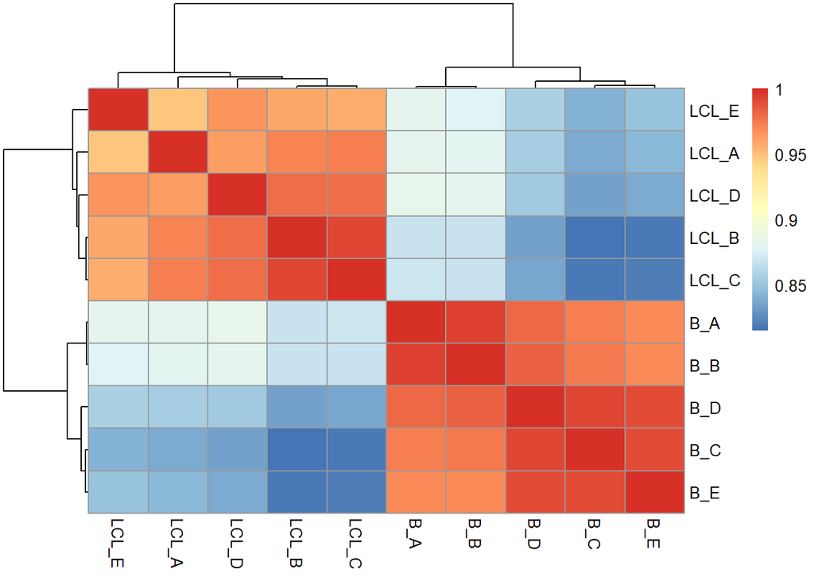

```r
rpkmMatrix<-log(rpkmMatrix+1)
correlation<-cor(rpkmMatrix, method = "pearson")
library(pheatmap)
pheatmap(correlation)
```

*How similar are the B-cell samples to each other?* ### B-cell samples are very similar to each other.

*The LCLs to each other?* ### LCLs also are very similar to each other.

*The B-cells to the LCLs?* ### B-cells are very different to LCLs.

*The donors are labeled [A-E]. What would we expect to see if there were donor-specific effects here (e.g. some donor-specific signal affecting both cell types)? Do we see them?* ###If there were donor-specific effects, we would expect to see higher correlation between bothe cell types in the donor, or the donor would not cluster well with other donors, however, I do not see obvious evidence.

#### Question 1d (4 pts)

*Plot the kernel density estimate for RPKM (x axis). Describe the distribution.*

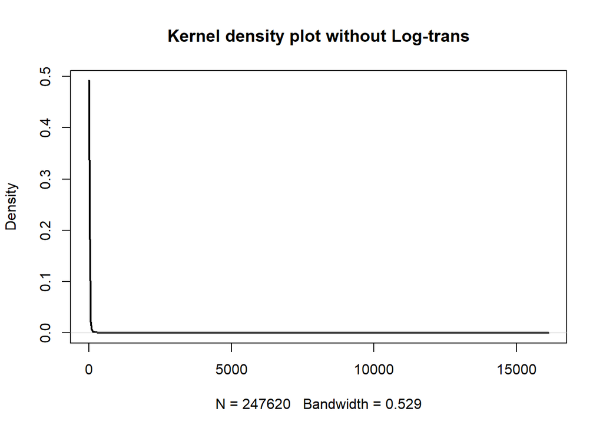

```r
kernel_d<-density(rnaSeqDataMeltedRPKM$RPKM)
plot(kernel_d, lwd = 2, main = "Kernel density plot without Log-trans")
```

###The distribution is very skew to left side of the plot.

*Plot the kernel density estimate for log(RPKM+1) (x axis). Describe the distribution.*

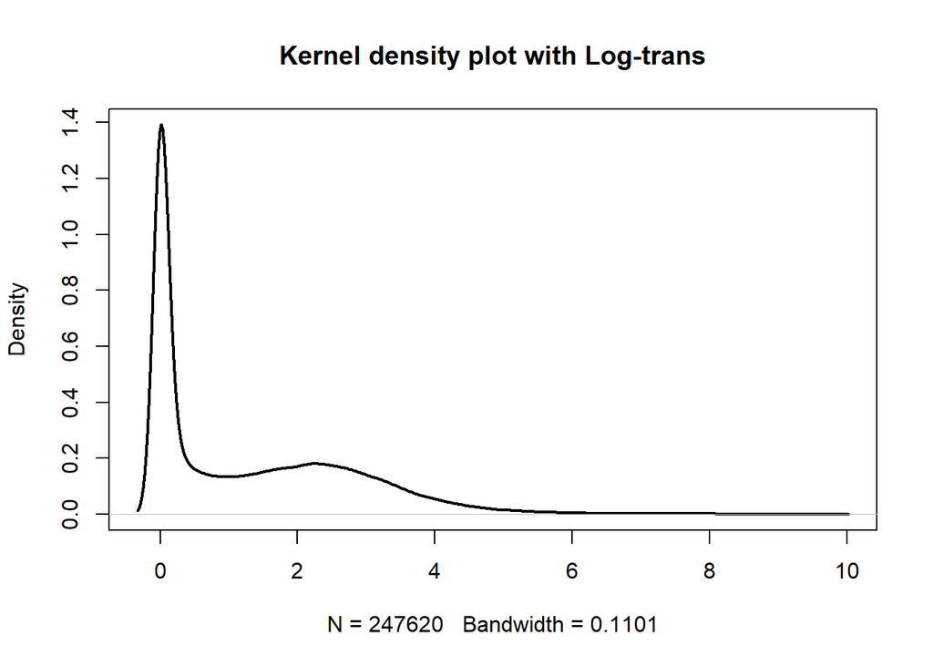

```r
kernel_d_log<-density(log(rnaSeqDataMeltedRPKM$RPKM+1))
plot(kernel_d_log, lwd = 2, main = "Kernel density plot with Log-trans")
```

###This time it is better to see the distribution, there are two peaks at around 0.1 and 2.5.

*Why do we log-transform gene expression data?* ###Because the original RPKM data have very large variance, some values are very large, this would cause the small values to be hard to see, thus we can not see the distribution clearly. Log-transform would reduce this variance while keep the difference between each values, and we can see the distribution clearly.

*Why do we use RPKM+1?* ###Because some values are 0, this would cause error when doing log transform, and RPKM+1 would finally result in 0, which is equal to the original one. Indeed, most of the RPKM values are larger than 1, values lower than 1 is not as such important.